# Shortest distance from a travel time matrix

Once you’ve created a travel time matrix using the `r5r` package, you can rearrange it to find the travel time to the closest destination.

# Required packages

This example uses the following packages.

```r
library(tidyverse)
library(sf)
library(ggspatial)
library(ggthemes)
library(knitr)
```

# Sample data

In this example, I’ve already calculated a travel time matrix from transit stops to polling locations in Somerville, Massachusetts.

```r
head(walk_to_polls) %>%
  kable()
```

| fromId | toId | travel_time |
| --- | --- | --- |
| 106 | 1 | 69 |
| 106 | 2 | 34 |
| 106 | 3 | 66 |
| 106 | 4 | 73 |
| 106 | 5 | 66 |
| 106 | 6 | 38 |

# Reshape data

I want a data set with a row for each polling place and column for the travel time to each transit station. I can use `pivot_wider()` to get my dataframe in that format.

I’ll end up with a data frame that has 19 rows (one for each polling place) and 650 (one for the polling place ID and 649 for all the transit stops).

Here, I’m showing just the first few rows an the first 15 columns.

```r
walk_to_polls_wide <- walk_to_polls %>%
  pivot_wider(names_from = fromId,
              values_from = travel_time)

head(walk_to_polls_wide[1:15]) %>%
  kable()
```

| toId | 106 | 11408 | 11410 | 12301 | 12376 | 12439 | 12451 | 12512 | 12530 | 12610 | 12615 | 12616 | 12636 | 12637 |
| --- | --- | --- | --- | --- | --- | --- | --- | --- | --- | --- | --- | --- | --- | --- |
| 1 | 69 | 69 | 77 | 24 | 33 | 64 | 64 | 62 | 61 | 62 | 50 | 47 | 25 | 28 |
| 2 | 34 | 17 | 25 | 38 | 80 | 16 | 15 | 10 | 9 | 10 | 8 | 10 | 74 | 77 |
| 3 | 66 | 63 | 71 | 21 | 34 | 60 | 60 | 56 | 55 | 56 | 45 | 43 | 33 | 36 |
| 4 | 73 | 73 | 81 | 28 | 26 | 68 | 68 | 66 | 65 | 66 | 54 | 51 | 15 | 18 |
| 5 | 66 | 66 | 74 | 21 | 35 | 61 | 61 | 59 | 58 | 59 | 47 | 44 | 25 | 28 |
| 6 | 38 | 37 | 46 | 14 | 62 | 32 | 32 | 30 | 29 | 30 | 16 | 14 | 51 | 55 |

# Calculate the minimum travel time

Now I can calculated the minimum travel time across all those columns. I’ll need to use `rowwise()` to indicate that I want to do calculations across columns rather than within columns. `c_across(-toID)` means I want to exclude the ID column from my calculation. Finally, I’ll rename `toId` as just `id` so I can easily join this variable to the polling place layer.

```r
walk_to_polls_min <- walk_to_polls_wide %>%
  rowwise() %>%
  mutate(min_time = min(c_across(-toId),na.rm = TRUE)) %>%
  select(toId, min_time) %>%
  rename(id = toId)
```

# Join data to layer

Now I can join the minimum travel time data to the layer with polling place locations

```r
polls <- polls %>%
  left_join(walk_to_polls_min)
```

# Map

And I can make a quick map to see how it all looks

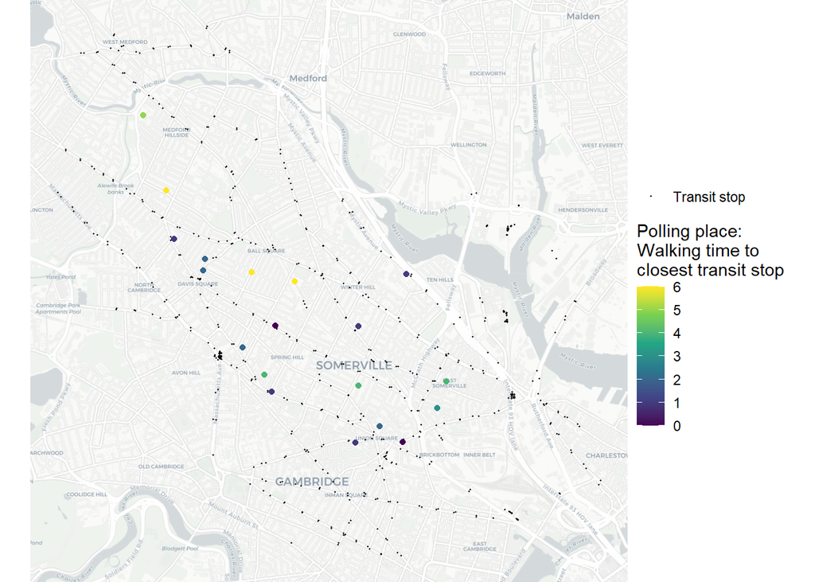

```r
ggplot() +
  annotation_map_tile(type = "cartolight", zoomin = 0) +
  geom_sf(data = transit,
          aes(shape = "Transit stop"),
          color = "black",
          size = 0.2) +
  geom_sf(data = polls,
          aes(color = min_time)) +
  scale_color_viridis_c(name =
          "Polling place:\nWalking time to\nclosest transit stop") +
  scale_shape(name = "") +
  theme_void()
```